# Data Wrangling

Practical assessment 2

Karim Aly

## **Setup**

```r
# Load the necessary packages required to reproduce the report. For example:

#install.packages("editrules")
library(editrules)
library(tidyr)

library(ggplot2)
library(dplyr)
library(moments)  # for skewness calculation
#install.packages("Hmisc")
library(Hmisc)

library(dplyr)
library(kableExtra)
library(magrittr)
library(readr)
```

## **Student names, numbers and percentage of contributions**

Group information

| Student name | Student number | Percentage of contribution |
| --- | --- | --- |
| Karim Aly | s4104031 | 50% |
| Bhanuchandu Bochu | s4120371 | 50% |

## **Executive Summary**

In this project, we integrated two datasets to create a unified dataset for comprehensive analysis. The primary objective was to prepare the data for further analytical tasks. The process began by importing the datasets and eliminating irrelevant columns to streamline the data. We decided to tidy and manipulate the data before merging the datasets, as one of them was not in a clean format and needed to be addressed first. We then merged the datasets into a single, cohesive dataset.

To better understand the data, various R scripts were used for exploratory analysis, providing insights into the data’s structure and attributes. Additionally, we created a new variable derived from two existing variables to enrich the dataset with more relevant information.

Next, we scanned the dataset for any missing values, special values, inconsistencies, and outliers. These issues were addressed using appropriate techniques, such as imputation for missing data and transformations to correct inconsistencies or outlier effects. As a final step, a transformation was applied to one of the variables to improve the data’s suitability for analysis.

## **Data**

The 2 dataset we used are obtained from the Kaggle website: -GDP per capita in US states is obtained from https://www.kaggle.com/datasets/solorzano/gdp-per-capita-in-us-states -USA Real Estate Dataset is obtained from https://www.kaggle.com/datasets/ahmedshahriarsakib/usa-real-estate-dataset/data

The first dataset provides information on GDP across various years for different U.S. states. It consists of seven columns: “Fips,” “Area,” and the years 2013 to 2017. The “Fips” column represents the unique code assigned to each state, while the “Area” column lists the state names. The columns for each year (2013, 2014, 2015, 2016, 2017) show the GDP values for the corresponding state in that particular year.

This second dataset is about real estate properties and includes various details about houses and their listings. It shows which real estate broker or agency is handling each property (“brokered_by”) and the current “status” of the property, such as whether it’s “ready for sale” or “ready to build.” The “price” is either the current listing price or the amount it was recently sold for if it’s no longer on the market. It also provides the number of bedrooms (“bed”) and bathrooms (“bath”) in the house, as well as the size of the land in acres (“acre_lot”). The location of the property is detailed through the street address (“street”), city, state, and postal code (“zip_code”). Additionally, the “house_size” indicates the living space in square feet. The dataset also keeps track of when the property was last sold (“prev_sold_date”).

```r
# Import the data, provide your R codes here.

# Import the data without column names
us_gdp_by_state_df <- read_csv("us-gdp-by-state.csv", show_col_types = FALSE)

#aus_real_estate_df$City <- toupper(aus_real_estate_df$City)

us_gdp_by_state_df <- us_gdp_by_state_df %>% filter(Area != "United States")
us_gdp_by_state_df <- us_gdp_by_state_df %>% select(c("Area", "2017"))

us_gdp_by_state_df <- us_gdp_by_state_df %>% add_row(Area = "Puerto Rico", `2017` = 31108)



# Display the first few rows of the data frame
print(head(us_gdp_by_state_df))
```

| Area | 2017 |
| --- | --- |
| Alabama | 37508 |
| Alaska | 63610 |
| Arizona | 39583 |
| Arkansas | 36714 |
| California | 60359 |
| Colorado | 54026 |

```r
us_realtor_df <- read.csv("us-realtor-data.csv", stringsAsFactors = TRUE)



print(tail(us_realtor_df))
```

|  | brokered_by | status | price | bed | bath | acre_lot | street | city | state | zip_code | house_size | prev_sold_date |
| --- | --- | --- | --- | --- | --- | --- | --- | --- | --- | --- | --- | --- |
| 1048570 | 3873 | for_sale | 523171 | 4 | 3 | 0.40 | 828186 | Harker Heights | Texas | 76548 | 2629 |  |
| 1048571 | 68915 | for_sale | 467847 | 5 | 4 | 0.19 | 773587 | Harker Heights | Texas | 76548 | 3499 |  |
| 1048572 | 68915 | for_sale | 345249 | 5 | 3 | 0.19 | 772323 | Harker Heights | Texas | 76548 | 2572 |  |
| 1048573 | 61150 | for_sale | 325000 | NA | NA | 0.68 | 1024251 | Harker Heights | Texas | 76548 | NA |  |
| 1048574 | 68915 | for_sale | 456122 | 5 | 4 | 0.19 | 273557 | Harker Heights | Texas | 76548 | 3499 |  |
| 1048575 | 61150 | for_sale | 325000 | NA | NA | 0.69 | 1024490 | Harker Heights | Texas | 76548 | NA |  |

Data Import and Filtering:

We starts by importing a CSV file named “us-gdp-by-state.csv” into a data frame called us_gdp_by_state_df, with the column names not being shown initially. The data represents GDP information by state in the United States. The data frame is then filtered to exclude any rows where the “Area” column equals “United States”, as the analysis is intended to be at the state level rather than the entire country. We added Puerto Rico to the dataset because it was missing.

We selected only the “Area” and “2017” columns, which represent the state names and their corresponding GDP for the year 2017.

Another dataset, “us-realtor-data.csv”, is imported into a data frame called us_realtor_df. This dataset contains real estate information by state.

## **Tidy & Manipulate Data I**

```r
# This is the R chunk for the Tidy & Manipulate Data I
us_gdp_by_state_df <- us_gdp_by_state_df %>% gather(`2017`, key = "year", value = "GDP")

tail(us_gdp_by_state_df)
```

| Area | year | GDP |
| --- | --- | --- |
| Plains | 2017 | 50145 |
| Southeast | 2017 | 42300 |
| Southwest | 2017 | 49902 |
| Rocky Mountain | 2017 | 48398 |
| Far West | 2017 | 58589 |
| Puerto Rico | 2017 | 31108 |

## **Merging Datasets**

```r
merged_df = merged_df <- left_join(us_realtor_df, us_gdp_by_state_df, by = c("state" = "Area"))
merged_df <- merged_df %>% select(-acre_lot)
print(tail(merged_df))
```

|  | brokered_by | status | price | bed | bath | street | city | state | zip_code | house_size | prev_sold_date | year | GDP |
| --- | --- | --- | --- | --- | --- | --- | --- | --- | --- | --- | --- | --- | --- |
| 1048570 | 3873 | for_sale | 523171 | 4 | 3 | 828186 | Harker Heights | Texas | 76548 | 2629 |  | 2017 | 53737 |
| 1048571 | 68915 | for_sale | 467847 | 5 | 4 | 773587 | Harker Heights | Texas | 76548 | 3499 |  | 2017 | 53737 |
| 1048572 | 68915 | for_sale | 345249 | 5 | 3 | 772323 | Harker Heights | Texas | 76548 | 2572 |  | 2017 | 53737 |
| 1048573 | 61150 | for_sale | 325000 | NA | NA | 1024251 | Harker Heights | Texas | 76548 | NA |  | 2017 | 53737 |
| 1048574 | 68915 | for_sale | 456122 | 5 | 4 | 273557 | Harker Heights | Texas | 76548 | 3499 |  | 2017 | 53737 |
| 1048575 | 61150 | for_sale | 325000 | NA | NA | 1024490 | Harker Heights | Texas | 76548 | NA |  | 2017 | 53737 |

## **Understand**

```r
print(str(merged_df))
```

```
'data.frame':   1048575 obs. of  13 variables:
 $ brokered_by   : int  103378 52707 103379 31239 34632 103378 1205 50739 81909 65672 ...
 $ status        : Factor w/ 2 levels "for_sale","ready_to_build": 1 1 1 1 1 1 1 1 1 1 ...
 $ price         : num  105000 80000 67000 145000 65000 179000 50000 71600 100000 300000 ...
 $ bed           : int  3 4 2 4 6 4 3 3 2 5 ...
 $ bath          : int  2 2 1 2 2 3 1 2 1 3 ...
 $ street        : int  1962661 1902874 1404990 1947675 331151 1850806 1298094 1048466 734904 1946226 ...
 $ city          : Factor w/ 15974 levels "","100 89 Lower Shepard Creek Road",..: 77 77 7068 11445 8738 12641 2614 11445 11445 7721 ...
 $ state         : chr  "Puerto Rico" "Puerto Rico" "Puerto Rico" "Puerto Rico" ...
 $ zip_code      : int  601 601 795 731 680 612 639 731 730 670 ...
 $ house_size    : int  920 1527 748 1800 NA 2520 2040 1050 1092 5403 ...
 $ prev_sold_date: Factor w/ 13848 levels "","1/1/1901",..: 1 1 1 1 1 1 1 1 1 1 ...
 $ year          : chr  "2017" "2017" "2017" "2017" ...
 $ GDP           : num  31108 31108 31108 31108 31108 ...
NULL
```

```r
summary(merged_df)
```

```
  brokered_by                status            price                bed              bath            street
 Min.   :     0   for_sale      :1031598   Min.   :0.000e+00   Min.   :  1.00   Min.   :  1.0    Min.   :      3
 1st Qu.: 23713   ready_to_build:  16977   1st Qu.:1.200e+05   1st Qu.:  3.00   1st Qu.:  2.0    1st Qu.: 530980
 Median : 52633                            Median :2.760e+05   Median :  3.00   Median :  2.0    Median :1064730
 Mean   : 51877                            Mean   :4.775e+05   Mean   :  3.31   Mean   :  2.5    Mean   :1055064
 3rd Qu.: 78838                            3rd Qu.:4.820e+05   3rd Qu.:  4.00   3rd Qu.:  3.0    3rd Qu.:1599512
 Max.   :110142                            Max.   :2.147e+09   Max.   :473.00   Max.   :752.0    Max.   :2001357
 NA's   :1038                              NA's   :1090        NA's   :310006   NA's   :324968   NA's   :6776
            city            state              zip_code       house_size        prev_sold_date       year                GDP
 Chicago      :  12688   Length:1048575     Min.   :    0   Min.   :      4            :550689   Length:1048575     Min.   : 31108
 New York City:   8248   Class :character   1st Qu.:25005   1st Qu.:   1312   29/4/2022:  2042   Class :character   1st Qu.: 39842
 Philadelphia :   8206   Mode  :character   Median :33950   Median :   1800   15/4/2022:  1493   Mode  :character   Median : 45925
 Miami        :   6128                      Mean   :37904   Mean   :   2138   22/4/2022:  1021                      Mean   : 48109
 Jacksonville :   5873                      3rd Qu.:53222   3rd Qu.:   2500   8/4/2022 :   736                      3rd Qu.: 53737
 New York     :   5297                      Max.   :99999   Max.   :9842382   6/5/2022 :   591                      Max.   :159607
 (Other)      :1002135                      NA's   :159     NA's   :364886    (Other)  :492003                      NA's   :758
```

```r
print(unique(merged_df$status))
```

```
[1] for_sale       ready_to_build
Levels: for_sale ready_to_build
```

```r
print(unique(merged_df$state))
```

```
 [1] "Puerto Rico"          "Virgin Islands"       "Massachusetts"        "Connecticut"          "New Hampshire"
 [6] "Vermont"              "New Jersey"           "New York"             "South Carolina"       "Tennessee"
[11] "Rhode Island"         "Virginia"             "Wyoming"              "Maine"                "Georgia"
[16] "Pennsylvania"         "West Virginia"        "Delaware"             "Louisiana"            "Ohio"
[21] "California"           "Colorado"             "Maryland"             "Missouri"             "District of Columbia"
[26] "Wisconsin"            "North Carolina"       "Kentucky"             "Michigan"             "Mississippi"
[31] "Florida"              "Alabama"              "New Brunswick"        ""                     "Texas"
[36] "Arkansas"             "Idaho"                "Indiana"              "Illinois"             "New Mexico"
[41] "Iowa"                 "Minnesota"            "South Dakota"         "Nebraska"             "North Dakota"
[46] "Montana"              "Oklahoma"             "Kansas"
```

```r
print(unique(us_gdp_by_state_df$Area))
```

```
 [1] "Alabama"              "Alaska"               "Arizona"              "Arkansas"             "California"
 [6] "Colorado"             "Connecticut"          "Delaware"             "District of Columbia" "Florida"
[11] "Georgia"              "Hawaii"               "Idaho"                "Illinois"             "Indiana"
[16] "Iowa"                 "Kansas"               "Kentucky"             "Louisiana"            "Maine"
[21] "Maryland"             "Massachusetts"        "Michigan"             "Minnesota"            "Mississippi"
[26] "Missouri"             "Montana"              "Nebraska"             "Nevada"               "New Hampshire"
[31] "New Jersey"           "New Mexico"           "New York"             "North Carolina"       "North Dakota"
[36] "Ohio"                 "Oklahoma"             "Oregon"               "Pennsylvania"         "Rhode Island"
[41] "South Carolina"       "South Dakota"         "Tennessee"            "Texas"                "Utah"
[46] "Vermont"              "Virginia"             "Washington"           "West Virginia"        "Wisconsin"
[51] "Wyoming"              "New England"          "Mideast"              "Great Lakes"          "Plains"
[56] "Southeast"            "Southwest"            "Rocky Mountain"       "Far West"             "Puerto Rico"
```

```r
merged_df$prev_sold_date <- as.Date(merged_df$prev_sold_date, format = "%d/%m/%Y")


print(str(merged_df))
```

```
'data.frame':   1048575 obs. of  13 variables:
 $ brokered_by   : int  103378 52707 103379 31239 34632 103378 1205 50739 81909 65672 ...
 $ status        : Factor w/ 2 levels "for_sale","ready_to_build": 1 1 1 1 1 1 1 1 1 1 ...
 $ price         : num  105000 80000 67000 145000 65000 179000 50000 71600 100000 300000 ...
 $ bed           : int  3 4 2 4 6 4 3 3 2 5 ...
 $ bath          : int  2 2 1 2 2 3 1 2 1 3 ...
 $ street        : int  1962661 1902874 1404990 1947675 331151 1850806 1298094 1048466 734904 1946226 ...
 $ city          : Factor w/ 15974 levels "","100 89 Lower Shepard Creek Road",..: 77 77 7068 11445 8738 12641 2614 11445 11445 7721 ...
 $ state         : chr  "Puerto Rico" "Puerto Rico" "Puerto Rico" "Puerto Rico" ...
 $ zip_code      : int  601 601 795 731 680 612 639 731 730 670 ...
 $ house_size    : int  920 1527 748 1800 NA 2520 2040 1050 1092 5403 ...
 $ prev_sold_date: Date, format: NA NA NA NA ...
 $ year          : chr  "2017" "2017" "2017" "2017" ...
 $ GDP           : num  31108 31108 31108 31108 31108 ...
NULL
```

In this R code, we perform some basic data exploration and data conversion tasks on the dataset `merged_df`. We begin by using the `str()` function to print the structure of `merged_df`, which gives us an overview of the dataset, including the data types of each column and a preview of the values.

Next, we use the `summary()` function to generate a statistical summary of the dataset, providing key information such as the minimum, median, mean, and maximum values for each numeric column, as well as counts for categorical columns.

We then print the unique values in the `status` column using the `unique()` function to understand the different categories present. Similarly, we use the `unique()` function to list the distinct values in the `state` column of `merged_df` and the `Area` column of dataset, `us_gdp_by_state_df`, which gives us an idea of the different states or areas covered in the data.

Finally, we convert the `prev_sold_date` column in `merged_df` to the date format using the `as.Date()` function with the specified format of “day/month/year”. After this transformation, we print the structure of `merged_df` again to confirm that the date conversion was successful and to see any changes in the data structure.

## **Tidy & Manipulate Data II**

```r
###Question NO 6


# Create a new variable 'price_per_sqft' using base R
merged_df$price_per_sqft <- merged_df$price / merged_df$house_size

# Display the first few rows of the updated dataframe
print(head(merged_df))
```

|  | brokered_by | status | price | bed | bath | street | city | state | zip_code | house_size | prev_sold_date | year | GDP | price_per_sqft |
| --- | --- | --- | --- | --- | --- | --- | --- | --- | --- | --- | --- | --- | --- | --- |
| 1 | 103378 | for_sale | 105000 | 3 | 2 | 1962661 | Adjuntas | Puerto Rico | 601 | 920 |  | 2017 | 31108 | 114.13043 |
| 2 | 52707 | for_sale | 80000 | 4 | 2 | 1902874 | Adjuntas | Puerto Rico | 601 | 1527 |  | 2017 | 31108 | 52.39031 |
| 3 | 103379 | for_sale | 67000 | 2 | 1 | 1404990 | Juana Diaz | Puerto Rico | 795 | 748 |  | 2017 | 31108 | 89.57219 |
| 4 | 31239 | for_sale | 145000 | 4 | 2 | 1947675 | Ponce | Puerto Rico | 731 | 1800 |  | 2017 | 31108 | 80.55556 |
| 5 | 34632 | for_sale | 65000 | 6 | 2 | 331151 | Mayaguez | Puerto Rico | 680 | NA |  | 2017 | 31108 | NA |
| 6 | 103378 | for_sale | 179000 | 4 | 3 | 1850806 | San Sebastian | Puerto Rico | 612 | 2520 |  | 2017 | 31108 | 71.03175 |

```r
# Summary statistics of the new variable
summary(merged_df$price_per_sqft)
```

```
     Min.   1st Qu.    Median      Mean   3rd Qu.      Max.      NA's
      0.0     130.4     182.6     254.4     257.9 2426535.1    365468
```

```r
print(tail(merged_df))
```

|  | brokered_by | status | price | bed | bath | street | city | state | zip_code | house_size | prev_sold_date | year | GDP | price_per_sqft |
| --- | --- | --- | --- | --- | --- | --- | --- | --- | --- | --- | --- | --- | --- | --- |
| 1048570 | 3873 | for_sale | 523171 | 4 | 3 | 828186 | Harker Heights | Texas | 76548 | 2629 |  | 2017 | 53737 | 199.0000 |
| 1048571 | 68915 | for_sale | 467847 | 5 | 4 | 773587 | Harker Heights | Texas | 76548 | 3499 |  | 2017 | 53737 | 133.7088 |
| 1048572 | 68915 | for_sale | 345249 | 5 | 3 | 772323 | Harker Heights | Texas | 76548 | 2572 |  | 2017 | 53737 | 134.2337 |
| 1048573 | 61150 | for_sale | 325000 | NA | NA | 1024251 | Harker Heights | Texas | 76548 | NA |  | 2017 | 53737 | NA |
| 1048574 | 68915 | for_sale | 456122 | 5 | 4 | 273557 | Harker Heights | Texas | 76548 | 3499 |  | 2017 | 53737 | 130.3578 |
| 1048575 | 61150 | for_sale | 325000 | NA | NA | 1024490 | Harker Heights | Texas | 76548 | NA |  | 2017 | 53737 | NA |

This code adds a new variable called `price_per_sqft` to the `merged_df` data frame. This new variable is calculated by dividing the house price (`price`) by the house size (`house_size`) for each row, giving the price per square foot of each property.The code then displays the first few rows of the updated data frame to confirm the new column was added correctly.

After that, it generates summary statistics for the `price_per_sqft` variable, providing insights such as the minimum, median, mean, and maximum values. Lastly, the script shows the last few rows of the modified data frame for further inspection.

## **Scan I**

```r
print(colSums(is.na(merged_df)))
```

```
   brokered_by         status          price            bed           bath         street           city          state
          1038              0           1090         310006         324968           6776              0              0
      zip_code     house_size prev_sold_date           year            GDP price_per_sqft
           159         364886         550689            758            758         365468
```

```r
# This is the R chunk for the Scan
```

```r
merged_df <- merged_df[complete.cases(merged_df[, c("brokered_by", "price", "street", "city", "zip_code", "GDP")]), ]
print(colSums(is.na(merged_df)))
```

```
   brokered_by         status          price            bed           bath         street           city          state
             0              0              0         306264         320411              0              0              0
      zip_code     house_size prev_sold_date           year            GDP price_per_sqft
             0         360699         544211              0              0         360699
```

```r
merged_df <- merged_df %>%
  group_by(city, state) %>%
   mutate(bed = ifelse( is.na(bed),
                        mean(bed[!is.na(bed)], na.rm = TRUE),
                        bed)) %>%
ungroup()

print(colSums(is.na(merged_df)))
```

```
   brokered_by         status          price            bed           bath         street           city          state
             0              0              0           5270         320411              0              0              0
      zip_code     house_size prev_sold_date           year            GDP price_per_sqft
             0         360699         544211              0              0         360699
```

```r
merged_df <- merged_df %>%
  filter(!is.na(bed))



print(colSums(is.na(merged_df)))
```

```
   brokered_by         status          price            bed           bath         street           city          state
             0              0              0              0         315167              0              0              0
      zip_code     house_size prev_sold_date           year            GDP price_per_sqft
             0         355503         539321              0              0         355503
```

```r
merged_df <- merged_df %>%
  group_by(city, state) %>%
   mutate(bath = ifelse( is.na(bath),
                        mean(bath[!is.na(bath)], na.rm = TRUE),
                        bath)) %>%
ungroup()

print(colSums(is.na(merged_df)))
```

```
   brokered_by         status          price            bed           bath         street           city          state
             0              0              0              0            786              0              0              0
      zip_code     house_size prev_sold_date           year            GDP price_per_sqft
             0         355503         539321              0              0         355503
```

```r
merged_df <- merged_df %>%
  filter(!is.na(bath))



print(colSums(is.na(merged_df)))
```

```
   brokered_by         status          price            bed           bath         street           city          state
             0              0              0              0              0              0              0              0
      zip_code     house_size prev_sold_date           year            GDP price_per_sqft
             0         355406         538553              0              0         355406
```

```r
merged_df <- merged_df %>%
  group_by(city, state) %>%
   mutate(house_size = ifelse( is.na(house_size),
                        mean(house_size[!is.na(house_size)], na.rm = TRUE),
                        house_size)) %>%
ungroup()

print(colSums(is.na(merged_df)))
```

```
   brokered_by         status          price            bed           bath         street           city          state
             0              0              0              0              0              0              0              0
      zip_code     house_size prev_sold_date           year            GDP price_per_sqft
             0           4208         538553              0              0         355406
```

```r
merged_df <- merged_df %>%
  filter(!is.na(house_size))



print(colSums(is.na(merged_df)))
```

```
   brokered_by         status          price            bed           bath         street           city          state
             0              0              0              0              0              0              0              0
      zip_code     house_size prev_sold_date           year            GDP price_per_sqft
             0              0         536045              0              0         351198
```

```r
merged_df <- merged_df %>%
  group_by(city, state) %>%
   mutate(price_per_sqft = ifelse( is.na(price_per_sqft),
                       price/house_size,
                        price_per_sqft)) %>%
ungroup()


print(colSums(is.na(merged_df)))
```

```
   brokered_by         status          price            bed           bath         street           city          state
             0              0              0              0              0              0              0              0
      zip_code     house_size prev_sold_date           year            GDP price_per_sqft
             0              0         536045              0              0              0
```

```r
print(colSums(is.na(merged_df)))
```

```
   brokered_by         status          price            bed           bath         street           city          state
             0              0              0              0              0              0              0              0
      zip_code     house_size prev_sold_date           year            GDP price_per_sqft
             0              0         536045              0              0              0
```

```r
#Define the rule
Rule1 <- editset(c("price > 0"))


# Find the violated edits
violations <- violatedEdits(Rule1, merged_df)


# Convert the violations matrix to a logical vector
violation_vector <- apply(violations, 1, any)

# Print the records that violated the rule
violated_records <- merged_df[violation_vector, ]

print(violated_records)
```

| brokered_by | status | price | bed | bath | street | city | state | zip_code | house_size | prev_sold_date | year | GDP | price_per_sqft |
| --- | --- | --- | --- | --- | --- | --- | --- | --- | --- | --- | --- | --- | --- |
| 67948 | for_sale | 0 | 5.127907 | 2.854651 | 1378257 | Paterson | New Jersey | 7504 | 4500.000 |  | 2017 | 56776 | 0 |
| 67948 | for_sale | 0 | 5.127907 | 2.854651 | 1385903 | Paterson | New Jersey | 7504 | 5000.000 |  | 2017 | 56776 | 0 |
| 92894 | for_sale | 0 | 4.000000 | 4.000000 | 1012209 | New York | New York | 10016 | 1774.869 |  | 2017 | 65220 | 0 |
| 67929 | for_sale | 0 | 2.892857 | 2.080134 | 360537 | Jersey City | New Jersey | 7302 | 1258.682 | 2020-03-04 | 2017 | 56776 | 0 |
| 67937 | for_sale | 0 | 2.445190 | 1.000000 | 1089831 | Queens | New York | 11101 | 1674.102 | 2021-08-31 | 2017 | 65220 | 0 |
| 32588 | ready_to_build | 0 | 2.000000 | 3.414634 | 1822284 | Cary | North Carolina | 27519 | 2114.000 |  | 2017 | 44706 | 0 |
| 32588 | ready_to_build | 0 | 2.000000 | 3.414634 | 1822284 | Cary | North Carolina | 27519 | 1776.000 |  | 2017 | 44706 | 0 |
| 32588 | ready_to_build | 0 | 2.000000 | 3.414634 | 1822284 | Cary | North Carolina | 27519 | 1888.000 |  | 2017 | 44706 | 0 |
| 32588 | ready_to_build | 0 | 2.000000 | 3.414634 | 1822284 | Cary | North Carolina | 27519 | 1519.000 |  | 2017 | 44706 | 0 |
| 32588 | ready_to_build | 0 | 2.000000 | 3.414634 | 1822284 | Cary | North Carolina | 27519 | 2058.000 |  | 2017 | 44706 | 0 |

[output cut: 82 more lines]

```r
merged_df <- merged_df %>% filter(price != 0)
```

```r
#Define the rule
Rule2 <- editset(c("bed > 0"))


# Find the violated edits
violations <- violatedEdits(Rule2, merged_df)


# Convert the violations matrix to a logical vector
violation_vector <- apply(violations, 1, any)

# Print the records that violated the rule
violated_records <- merged_df[violation_vector, ]

print(violated_records)
```

| brokered_by | status | price | bed | bath | street | city | state | zip_code | house_size | prev_sold_date | year | GDP | price_per_sqft |
| --- | --- | --- | --- | --- | --- | --- | --- | --- | --- | --- | --- | --- | --- |

```r
#Define the rule
Rule3 <- editset(c("bath > 0"))


# Find the violated edits
violations <- violatedEdits(Rule3, merged_df)


# Convert the violations matrix to a logical vector
violation_vector <- apply(violations, 1, any)

# Print the records that violated the rule
violated_records <- merged_df[violation_vector, ]

print(violated_records)
```

| brokered_by | status | price | bed | bath | street | city | state | zip_code | house_size | prev_sold_date | year | GDP | price_per_sqft |
| --- | --- | --- | --- | --- | --- | --- | --- | --- | --- | --- | --- | --- | --- |

```r
#Define the rule
Rule4 <- editset(c("house_size > 0"))


# Find the violated edits
violations <- violatedEdits(Rule4, merged_df)


# Convert the violations matrix to a logical vector
violation_vector <- apply(violations, 1, any)

# Print the records that violated the rule
violated_records <- merged_df[violation_vector, ]

print(violated_records)
```

| brokered_by | status | price | bed | bath | street | city | state | zip_code | house_size | prev_sold_date | year | GDP | price_per_sqft |
| --- | --- | --- | --- | --- | --- | --- | --- | --- | --- | --- | --- | --- | --- |

```r
#Define the rule
Rule5 <- editset(c("GDP > 0"))


# Find the violated edits
violations <- violatedEdits(Rule5, merged_df)


# Convert the violations matrix to a logical vector
violation_vector <- apply(violations, 1, any)

# Print the records that violated the rule
violated_records <- merged_df[violation_vector, ]

print(violated_records)
```

| brokered_by | status | price | bed | bath | street | city | state | zip_code | house_size | prev_sold_date | year | GDP | price_per_sqft |
| --- | --- | --- | --- | --- | --- | --- | --- | --- | --- | --- | --- | --- | --- |

We filled the missing values in the ‘bed’ column by calculating the average number of beds for each group based on `city` and `state`. After filling in these values, we removed any remaining rows with missing ‘bed’ values. This process is repeated for the ‘bath’ column, where missing values are replaced with the average for each group, followed by removing any rows where ‘bath’ is still missing. The same method is applied to the ‘house_size’ column. Lastly, we calculated ‘price_per_sqft’ for any missing values by dividing ‘price’ by ‘house_size’. Throughout the script, the number of missing values is monitored to ensure the dataset is being cleaned effectively.

We uses the `editrules` package to check the quality of our dataset, `merged_df`. First, we load the package and create a rule, `Rule1`, which says that the `price` must be greater than 0. We then use the `violatedEdits` function to find any records in `merged_df` that don’t follow this rule. The violations are saved in a matrix, which we change into a logical vector called `violation_vector` using the `apply` function. This vector shows which records have issues, and we extract and print these problematic records from `merged_df`.

We do the same thing for the `bed`, `house_size`, and `GDP` columns using `Rule2`, `Rule4`, and `Rule5`. Each time, we set a rule that checks if the values in those columns are greater than 0. We identify any violations, turn them into a logical vector, and print them out.

Finally, we can clean our dataset by removing rows that don’t meet the rules. For example, after finding records with a `price` of 0, we filter `merged_df` to get rid of those records, making sure only valid data is left for our analysis.

## **Scan II**

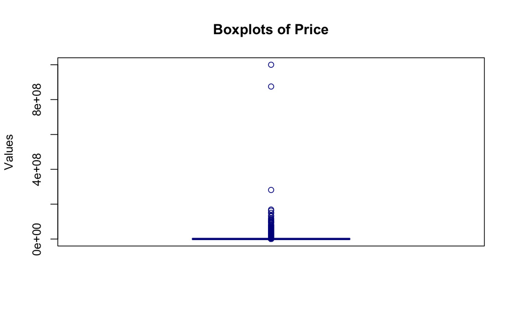

```r
# Create boxplots for the numeric columns
boxplot(merged_df$price,
        main = "Boxplots of Price", # Title of the boxplot
        ylab = "Values",                       # Y-axis label
        col = c("lightblue", "lightgreen", "lightpink"), # Colors for each boxplot
        border = "darkblue")
```

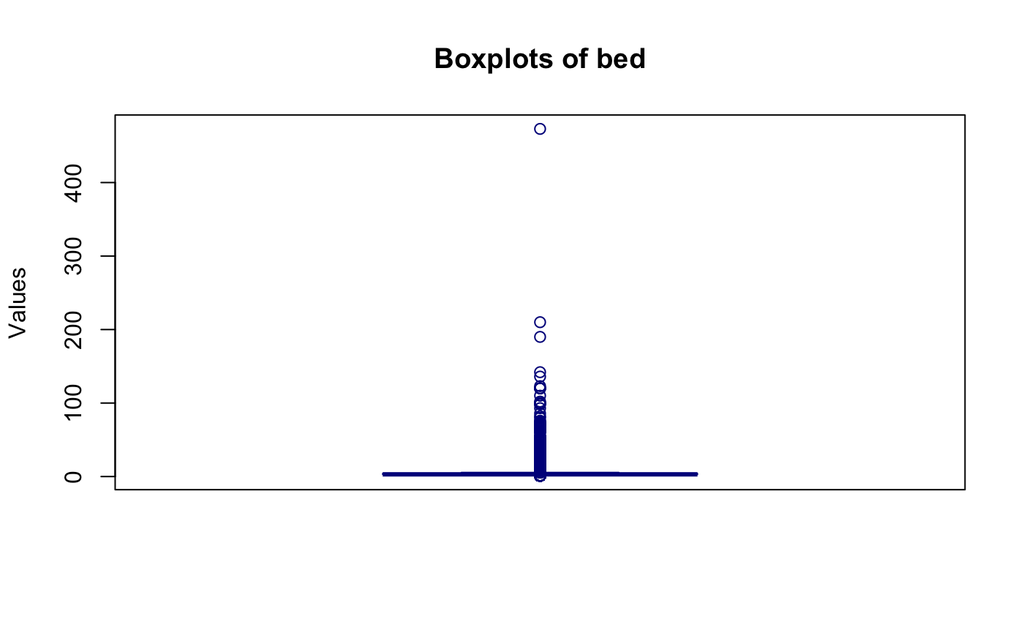

```r
# Create boxplots for the numeric columns
boxplot(merged_df$bed,
        main = "Boxplots of bed", # Title of the boxplot
        ylab = "Values",                       # Y-axis label
        col = c("lightblue", "lightgreen", "lightpink"), # Colors for each boxplot
        border = "darkblue")
```

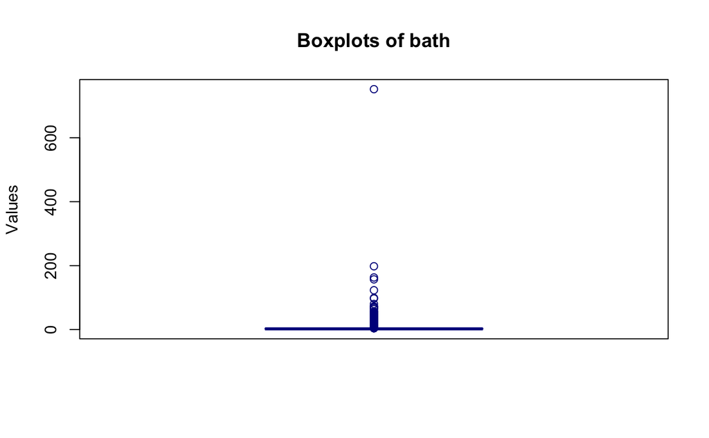

```r
# Create boxplots for the numeric columns
boxplot(merged_df$bath,
        main = "Boxplots of bath", # Title of the boxplot
        ylab = "Values",                       # Y-axis label
        col = c("lightblue", "lightgreen", "lightpink"), # Colors for each boxplot
        border = "darkblue")
```

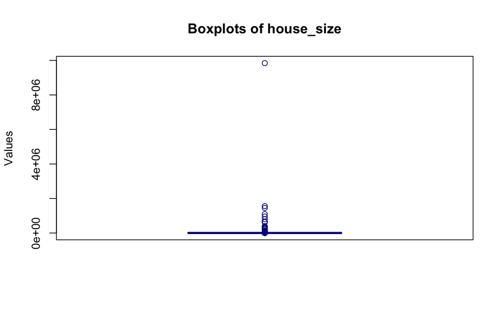

```r
# Create boxplots for the numeric columns
boxplot(merged_df$house_size,
        main = "Boxplots of house_size", # Title of the boxplot
        ylab = "Values",                       # Y-axis label
        col = c("lightblue", "lightgreen", "lightpink"), # Colors for each boxplot
        border = "darkblue")
```

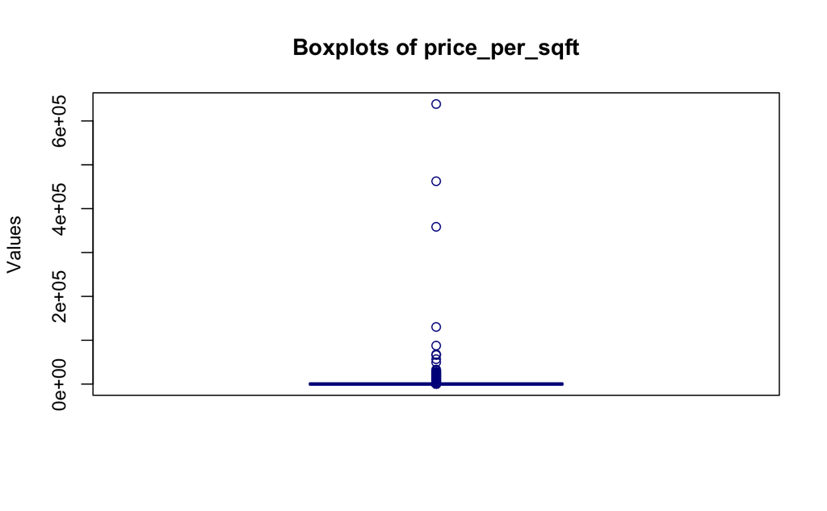

```r
# Create boxplots for the numeric columns
boxplot(merged_df$price_per_sqft,
        main = "Boxplots of price_per_sqft", # Title of the boxplot
        ylab = "Values",                       # Y-axis label
        col = c("lightblue", "lightgreen", "lightpink"), # Colors for each boxplot
        border = "darkblue")
```

```r
# Define a function to replace outliers with the median of the column
replace_outliers_with_median <- function(column) {
  # Calculate the first and third quartile
  Q1 <- quantile(column, 0.25, na.rm = TRUE)
  Q3 <- quantile(column, 0.75, na.rm = TRUE)

  # Calculate the Interquartile Range (IQR)
  IQR_value <- IQR(column, na.rm = TRUE)

  # Define lower and upper bounds for outliers
  lower_bound <- Q1 - 1.5 * IQR_value
  upper_bound <- Q3 + 1.5 * IQR_value

  # Calculate the median of the column
  median_value <- median(column, na.rm = TRUE)

  # Replace values outside the bounds with the median
  column[column < lower_bound | column > upper_bound] <- median_value

  # Return the modified column
  return(column)
}

# Specify the columns where you want to replace outliers
columns_to_modify <- c("price", "bed", "bath", "house_size", "price_per_sqft")

# Apply the function only to the specified columns
df <- merged_df

df[columns_to_modify] <- lapply(df[columns_to_modify], replace_outliers_with_median)

merged_df <- df

# View the modified dataframe
print(merged_df)
```

| brokered_by | status | price | bed | bath | street | city | state | zip_code | house_size | prev_sold_date | year | GDP | price_per_sqft |
| --- | --- | --- | --- | --- | --- | --- | --- | --- | --- | --- | --- | --- | --- |
| 103378 | for_sale | 105000 | 3.000000 | 2.000000 | 1962661 | Adjuntas | Puerto Rico | 601 | 920.000 |  | 2017 | 31108 | 114.130435 |
| 52707 | for_sale | 80000 | 4.000000 | 2.000000 | 1902874 | Adjuntas | Puerto Rico | 601 | 1527.000 |  | 2017 | 31108 | 52.390308 |
| 103379 | for_sale | 67000 | 2.000000 | 1.000000 | 1404990 | Juana Diaz | Puerto Rico | 795 | 748.000 |  | 2017 | 31108 | 89.572193 |
| 31239 | for_sale | 145000 | 4.000000 | 2.000000 | 1947675 | Ponce | Puerto Rico | 731 | 1800.000 |  | 2017 | 31108 | 80.555556 |
| 34632 | for_sale | 65000 | 3.000000 | 2.000000 | 331151 | Mayaguez | Puerto Rico | 680 | 2004.533 |  | 2017 | 31108 | 32.426500 |
| 103378 | for_sale | 179000 | 4.000000 | 3.000000 | 1850806 | San Sebastian | Puerto Rico | 612 | 2520.000 |  | 2017 | 31108 | 71.031746 |
| 1205 | for_sale | 50000 | 3.000000 | 1.000000 | 1298094 | Ciales | Puerto Rico | 639 | 2040.000 |  | 2017 | 31108 | 24.509804 |
| 50739 | for_sale | 71600 | 3.000000 | 2.000000 | 1048466 | Ponce | Puerto Rico | 731 | 1050.000 |  | 2017 | 31108 | 68.190476 |
| 81909 | for_sale | 100000 | 2.000000 | 1.000000 | 734904 | Ponce | Puerto Rico | 730 | 1092.000 |  | 2017 | 31108 | 91.575092 |
| 65672 | for_sale | 300000 | 5.000000 | 3.000000 | 1946226 | Las Marias | Puerto Rico | 670 | 1919.000 |  | 2017 | 31108 | 55.524708 |

[output cut: 990 more lines]

In this R code, we create boxplots for several numeric columns in the dataset `merged_df` to visualize their distributions and identify any outliers. We then clean the data by replacing outliers with the median values for each column.

We start by generating boxplots for the columns `price`, `bed`, `bath`, `house_size`, and `price_per_sqft`. Each boxplot shows the range of values in the column, with any outliers displayed outside the “box” (representing the interquartile range). We customize the boxplots with titles, axis labels, and colors to make them easier to interpret.

Next, we define a function, `replace_outliers_with_median`, to clean the data by replacing outlier values. The function first calculates the first (Q1) and third (Q3) quartiles for a column and uses these to find the interquartile range (IQR). The lower and upper bounds for outliers are set to 1.5 times the IQR below Q1 and above Q3, respectively. Any values falling outside these bounds are considered outliers and are replaced with the median (middle) value of the column.

We then specify which columns we want to clean (`price`, `bed`, `bath`, `house_size`, and `price_per_sqft`) and apply the outlier-replacement function to these columns. After modifying the specified columns, we update `merged_df` with the cleaned data. Finally, we print the updated dataset to check the changes.

## **Transform**

```r
#question 9


# This is the R chunk for the Transform Section


# Assuming 'merged_df' contains the variable 'price_per_sqft'
# We will apply a log transformation to 'price_per_sqft' to reduce skewness

# Check skewness before transformation
skewness_before <- skewness(merged_df$price_per_sqft, na.rm = TRUE)
print(paste("Skewness before log transformation:", skewness_before))
```

```
[1] "Skewness before log transformation: 0.702272605518312"
```

```r
# Apply log transformation
merged_df$log_price_per_sqft <- log(merged_df$price_per_sqft)

# Check skewness after transformation
skewness_after <- skewness(merged_df$log_price_per_sqft, na.rm = TRUE)
print(paste("Skewness after log transformation:", skewness_after))
```

```
[1] "Skewness after log transformation: -1.84622741049758"
```

```r
# Visualizing the distribution before and after transformation
par(mfrow = c(1, 2))
hist(merged_df$price_per_sqft, main = "Price per Sqft (Before)", xlab = "Price per Sqft", col = "blue")
hist(merged_df$log_price_per_sqft, main = "Log-Transformed Price per Sqft", xlab = "Log(Price per Sqft)", col = "green")
```

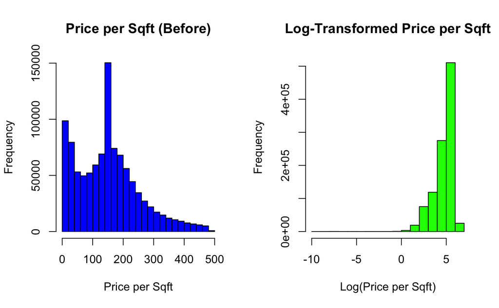

```r
par(mfrow = c(1, 1))
```

In this R code, we aim to reduce the skewness of the price_per_sqft variable in our dataset, by applying a log transformation. First, we calculate and print the skewness of price_per_sqft before applying any transformations to see how skewed the data is.

After applying the log transformation, we calculate the skewness again for the new log_price_per_sqft column and print the result to see if the transformation effectively reduced the skewness. Finally, we visualize the distributions before and after the transformation by plotting histograms side by side. One histogram shows the original price_per_sqft, and the other shows the log-transformed values, allowing us to compare the distributions and see the effect of the transformation.

## **Presentation**

Karim Aly : https://rmit-arc.instructuremedia.com/embed/39640fa6-398c-43c0-96aa-0f4e84eeb553

Bhanuchandu Bochu: https://rmit-arc.instructuremedia.com/embed/372b1b4d-5ba3-44be-9e42-3f1e403f200c